# Linkage mapping workshop

Lorenzo Bertola

Document last run on 2023-10-11

## 1. Setup

Load some useful packages. At the start I mostly use these to provide prettier explanations (e.g., a table of genotype proportions), but later on we will use them to investigate our results.

```r
library(tidyverse)
library(knitr)
library(ggpubr)
```

We will be running this workshop from an IDE, to directly access the HPC (for JCU students) or the research computing facility of your institution. For this I follow the blog post by Wytamma Wirth, found [here](https://blog.wytamma.com/blog/hcp-vscode/). For more infor check Wytamma’s post.

### 1.1. Install Visual Studio Code (VSC)

First thing will be to download Visual Studio Code. To dowload and install, select download at this [link](https://code.visualstudio.com/) and then follow the instructions for installing.

Once installed, select the *Extensions* tab on the left, and search for the *Remote - SSH* extension by Microsoft, which will allow us to connect to the HPC from VSC. Once you found the extension, press ‘install’.

If installed correctly, a new option will appear on the left called *Remote explorer*.

From remote explorer, you will need to select the *+* sign next to SSH, and follow the prompts to connect to your university’s HPC. This can vary a lot based on your university’s server so we will do that in person for troubleshooting. Crucially, you will first have to connect to the HPC. At this stage you will only connect to your home folder. Then, once logged in, make a directory for this workshop (I called mine *LinkageMapWorkshop*), then select *Open folder* and select the workshop folder. You will be prompted to enter your password again. From now on, if it worked, you should be able to connect directly to the project folder.

Now that we started a new session in the project folder, we can start setting up our data, software and so on.

*IMPORTANT* the bash commands you will see here, like the `pwd` command below, should be run from the terminal within Visual Studio Code from the project home directory for them to work. If you are running from a different directory adjust the path accordingly.

First thing, from the Terminal within Visual Studio code, run the `pwd` command and check the output.

```bash
pwd
```

[figure not shown]

Our working directory is now the project folder, handy!

### 1.1. Download software

Now, let’s download lepmap and set it up within our project directory. Lepmap comes as a set of executable files to be run with java, so we can download these and store them in a folder within our project directory.

The LepMap executables can be found at the following [link](https://sourceforge.net/projects/lep-map3/). Once downloaded, we can simply drag into our project directory on visual studio code (note: this is a very small file, for larger files it is better to use FileZilla, scp, etc).

We can then unzip the lepmap binary files and store into a folder called *lepmap*. Assuming we have added the zipped file to the project directory, we can unzip with:

```bash
unzip binary.zip -d lepmap
```

The binary lepmap files are contained within the *bin* folder.

### 1.2. Import data

Now, let’s make a folder for our raw data.

```bash
mkdir -p 1_rawdata
```

And a folder for any script we will prepare

```bash
mkdir -p scripts
```

Now that we have prepared the required directories, we can import our raw data into the *rawdata* folder. Once again, for a single family with ~150 F1 offspring and ~20-30k markers the file will be small enough that we can simply drag it to the rawdata folder in VSC, otherwise use your preferred file transfer protocol (e.g., scp, FileZilla).

The input file should look like the below:

```bash
cat ../1_rawdata/input_fam1.txt | head -n 10 | cut -f-5
```

```
## CHR  POS LM_LM_KI    LM_LM_KI    LM_LM_KI
## CHR  POS LM_LM_KI_MOT_F1 LM_LM_KI_FAT_M1 LM_LM_KI_001
## CHR  POS 0   0   LM_LM_KI_FAT_M1
## CHR  POS 0   0   LM_LM_KI_MOT_F1
## CHR  POS 2   1   0
## CHR  POS 999 999 999
## 5_27 POS 0 1.0 0 0 0 0 0 0 0 0   0 1.0 0 0 0 0 0 0 0 0   0 1.0 0 0 0 0 0 0 0 0
## 14_29    POS 0 1.0 0 0 0 0 0 0 0 0   0 1.0 0 0 0 0 0 0 0 0   0 0 0 0 1.0 0 0 0 0 0
## 53_19    POS 0 1.0 0 0 0 0 0 0 0 0   0 1.0 0 0 0 0 0 0 0 0   0 1.0 0 0 0 0 0 0 0 0
## 54_52    POS 0 1.0 0 0 0 0 0 0 0 0   0 1.0 0 0 0 0 0 0 0 0   0 1.0 0 0 0 0 0 0 0 0
```

The first six rows represent the individuals metadata (with 2 placeholder columns containing CHR and POS). The six rows indicate:

1. The unique family ID, where a family represent a group of offspring and their 2 shared parents.
2. The unique sample/individual ID
3. The ID of the father (0 if unknown)
4. The ID of the mother (0 if unknown)
5. The sex of the individual (2 female, 1 male, 0 unknown)
6. The phenotype (999 is unknown)

After that, for unmapped data, each row contains the marker ID, followed by a POS placeholder, and the genotype data. If you have mapped data, the first two columns will be the scaffold/chromosome ID, followed by the position in base pairs.

Genotype data is reported as a likelihood, with 10 possible values per individual representing the likelihood of each of the 10 possible genotypes (AA, AT, AG, AC, TT, TG, TC, GG, GC, CC). To denote missing data just leave all 10 as zero.

## 2. Filter data by segregation distortion

Let’s expand this to a whole family cross. Let’s assume that the parents once again both have AT genotypes (i.e., they are both heterozygous). We can then call this marker a *double heterozygote* marker. Then, in the offspring, we will expect a certain proportion of genotypes following mendelian inheritance.

| parent.genotypes | A | T |
| --- | --- | --- |
| A | AA | AT |
| T | AT | TT |

Looking at this table, we can see that if the two alleles from each parent are matched at random, we should expect 1/4 of offspring to have a AA genotype (homozygous reference), 1/4 to have a TT genotype (homozygous snp), and 1/4*2 to have AT genotype (heterozygous).

Based on this expectation, we can then discard markers where the offspring genotype proportions are too different from our expectation (i.e., have high segregation distortion).

Additionally, we can call the parent genotypes. Imagine for instance the case where we have one parent with an AT genotype and one parent with no genotype (i.e., missing data), with 25% of offspring with AA, 25% with TT and 50% with AT. Then we can be confident that the missing parent also has an AT genotype and we can thus impute it. Note that in this case, the more offspring you have the more accurate these two steps (assessing segregation distortion and imputing parent genotypes) are going to be.

LepMap comes with its own functions to both call the parent genotypes as well as filter based off segregation distortion, called *ParentCall2* and *Filtering2* respectively.

### 2.1. Correct and/or impute parent genotypes

First, let’s make a folder where to store the filtered data

```bash
mkdir -p 2_filtered
```

Then we can run the ParentCall2 and Filtering2 modules of lepmap. Depending on the size of your data, these should not take too long, but for good etiquette given we are using the HPC we will submit them as PBS scripts nonetheless.

*IMPORTANT*: Note that for this workshop I assume that your data has already gone through some level of filtering to retain only high-quality markers. The exact filtering will depend on your sequencing platform and data type, thus I do not discuss this here.

Let’s prepare a script to run the lepmap filtering modules.

```bash
#!/bin/bash

#PBS -j oe
#PBS -N lepmap.parentcall
#PBS -l nodes=1:ppn=1
#PBS -l mem=5gb
#PBS -l walltime=05:00:00

# Set directory to your project folder
# you will need to change this to match
# your folder name and path
cd ~/LinkageMapWorkshop

# Run the Parent call module
java -cp lepmap/bin/ ParentCall2 \
  data=1_rawdata/input_fam1.txt \
  removeNonInformative=1 > 2_filtered/2_1_filtered_fam1

# Run the filtering module
# We will run a few different parameter sets to
# assess their influence on the output

# DEFAULT parameters
java -cp lepmap/bin/ Filtering2 \
  data=2_filtered/2_1_filtered_fam1 \
  dataTolerance=0.001 > 2_filtered/2_2_filtered_fam1_default

# CONSERVATIVE segregation distortion
java -cp lepmap/bin/ Filtering2 \
  data=2_filtered/2_1_filtered_fam1 \
  dataTolerance=0.00001 > 2_filtered/2_2_filtered_fam1_conservative

# MAF (Minor Allele Frequency)
java -cp lepmap/bin/ Filtering2 \
  data=2_filtered/2_1_filtered_fam1 \
  dataTolerance=0.001 \
  MAFLimit=0.01 > 2_filtered/2_2_filtered_fam1_maf

# Missing data
java -cp lepmap/bin/ Filtering2 \
  data=2_filtered/2_1_filtered_fam1 \
  dataTolerance=0.001 \
  missingLimit=0.2 > 2_filtered/2_2_filtered_fam1_missing
```

Then, from the terminal window, submit it with:

```bash
qsub scripts/2_filtering.sh
```

Note how we are running Filtering2 with a few different parameters, to better understand their effect on the resulting data.

#### 2.1.1. Segregation distortion

The segregation distortion parameter represents the p-value limit at which a marker is considered to be deviating from the expected genotype proportions. This parameter is very susceptible to the per-family sample size, the error rate and coverage in the data.

Very *large families* (i.e., >100-300 offspring) with *high coverage* and *low error rate* can use lower values for this parameter, as observed genotype proportions will match the expected proportions really well, and only a handful of individuals (~ < 1% of offspring per family) will contain erroneous genotypes skewing the observed proportions.

On the other hand, for *smaller families* with *medium-low coverage* and *high error rates*, this parameter will need to be kept at the default of 0.001 or increased.

#### 2.1.2. Minor allele frequency

The minor allele frequency parameter works as usual in population genetics: markers with very few copies of the less frequent allele are removed as they are likely to result from sequencing and/or genotyping errors.

I personally do not use this very often in linkage mapping as filtering by segregation distortion will address this pretty well, and in larger families (~ > 50 offspring) the minor allele frequency will usually be minimum of 25% for correctly sequenced and genotyped markers, and those with a MAF < 10-15% will be removed by the segregation distortion filter already.

Nevertheless, we will include it to see how it affects our data.

#### 2.1.3. Missing data

Finally, let’s filter based on missing data. This will be particularly useful in this case to remove mis-genotyped markers. For instance if using stacks with the denovo approach some of your alleles from the same marker might be built as 2 different loci, thus resulting in a high level of missing data.

### 2.2. Assess impact of filtering

Let’s assess how the different filtering steps changed the number of retained markers.

```bash
echo "default ="`cat ../2_filtered/2_2_filtered_fam1_default | wc -l`" markers"
echo "conservative ="`cat ../2_filtered/2_2_filtered_fam1_conservative | wc -l`" markers"
echo "maf ="`cat ../2_filtered/2_2_filtered_fam1_maf | wc -l`" markers"
echo "missing ="`cat ../2_filtered/2_2_filtered_fam1_missing | wc -l`" markers"
```

```
## default = 8534 markers
## conservative = 8534 markers
## maf = 8534 markers
## missing = 8534 markers
```

*NOTE* The example data being used was filtered manually in R with custom R scripts. It was filtered very conservatively already so the different filters do not change the resulting number of markers. I have left that code there for you to see and use with your data. If you are interested in the custom R filteiring pipeline, check the [paper](https://www.nature.com/articles/s41437-023-00642-5) and the [code](https://mboitui.github.io/HighDensityLinkageMap/) used.

## 3. Assign markers to linkage groups

The next step once we have nice clean data is to assign the markers to putative chromosomes, known within linkage mapping as *linkage groups*.

This step is done with the `SeparateChromosomes2` module of lepmap. The format for this module is like the below:

`SeparateChromosomes2 data=input.file lodLimit=NUM sizeLimit=NUM numThreads=NUM > output.file.txt`

These main parameters represent:

- data: the input file output by Filtering2 and/or ParentCall2
- lodLimit: the minimum LOD score for a marker to be assigned to a linkage group
- sizeLimit: the minimum numbers of markers in a linkage group for that linkage group to be retained
- numThreads: number of threads. . . .

Let’s run it once with the default lodLimit value and without a sizeLimit option. If you have less than ~150 offspring and less than ~20k markers you can probably run from a login node. To achieve this i submit the following on the terminal within Visual Studio Code.

```bash
java -cp lepmap/bin/ SeparateChromosomes2 \
  data=2_filtered/2_2_filtered_fam1_default \
  lodLimit=10 > temp/tempfile1.txt
```

The output file, `tempfile1.txt`, contains a single column where the number indicates the linkage group a marker was assigned to. While there is no markerID, the rows are in the same order as the markers in the input file.

```bash
cat ../temp/tempfile1.txt | head
```

```
## #java SeparateChromosomes2  data=filtered/filtered_2_fam1_default lodLimit=10
## 6
## 3
## 2
## 2
## 2
## 1
## 5
## 5
## 2
```

In this file for instance the first marker is assigned to linkage group 6, the second to linkage group 3, etc.

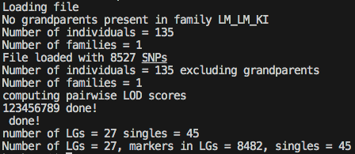

Looking at the log, using the example data provided, from a cross of Kuranda Treefrogs with 133 offspring and 2 parents, and 8527 SNPs, all but 45 markers were assigned to a linkage group, and a total of 27 linkage groups (LGs) were retained. The species has 13 chromosomes, so at this stage we recovered more linkage groups than there are chromosomes. Let’s see how many markers are present in linkage group to start understanding this pattern.

```bash
cut -f 1 ../temp/tempfile1.txt | sort | uniq -c | sort -k2 -n | tail -n +2
```

```
##   45 0
## 1785 1
## 1048 2
##  967 3
##  890 4
##  714 5
##  596 6
##  505 7
##  483 8
##  468 9
##  370 10
##  352 11
##  256 12
##    7 13
##    5 14
##    4 15
##    4 16
##    4 17
##    4 18
##    3 19
##    3 20
##    2 21
##    2 22
##    2 23
##    2 24
##    2 25
##    2 26
##    2 27
```

This file shows us on the left the number of markers assigned to a linkage group, and on the right the id of the linkage group. Lepmap names linkage group sequentially based on how many markers they contain.

From this we can see that we have 45 markers assigned to no linkage group (first row). Then, we have 12 linkage groups with more than 250 markers each, while the remaining linkage groups have less than 10 markers. To address this, we can use the `sizeLimit` parameter to exclude linkage groups with too few markers to be biologically sensible.

```bash
java -cp lepmap/bin/ SeparateChromosomes2 \
  data=2_filtered/2_2_filtered_fam1_default \
  lodLimit=10 sizeLimit=50 > temp/tempfile2.txt
```

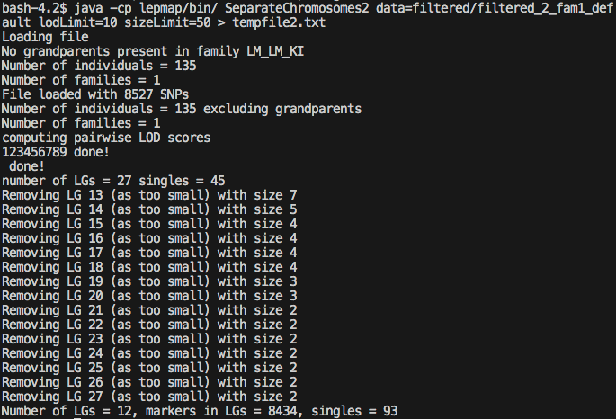

We can see now that all the small linkage groups were removed (i.e., the markers were assigned to linkage group 0), and we have identified a total of 12 LGs. This is a lot closer to the expected 13 linkage groups based on our knowledge for the species. Let’s assess the number of markers per linkage group to see where this might be coming from.

```bash
cut -f 1 ../temp/tempfile2.txt | sort | uniq -c | sort -k2 -n | tail -n +2
```

```
##   93 0
## 1785 1
## 1048 2
##  967 3
##  890 4
##  714 5
##  596 6
##  505 7
##  483 8
##  468 9
##  370 10
##  352 11
##  256 12
```

We can see that we have 93 marker not assigned to any linkage group, and that the number of markers then decreases somewhat linearly, except between the 1st and 2nd linkage group. Let’s plot this to have a better understanding of this.

```bash
cut -f 1 ../temp/tempfile2.txt | sort | uniq -c | sort -k2 -n | tail -n +2 > ../temp/tempfile2.tsv
```

```r
tempdf <- read_delim("../temp/tempfile2.tsv", delim = " ",
                     col_names = c("Markers","LG"))

# Adjust data type
tempdf <- tempdf %>%
  mutate(Markers = as.integer(Markers))
```

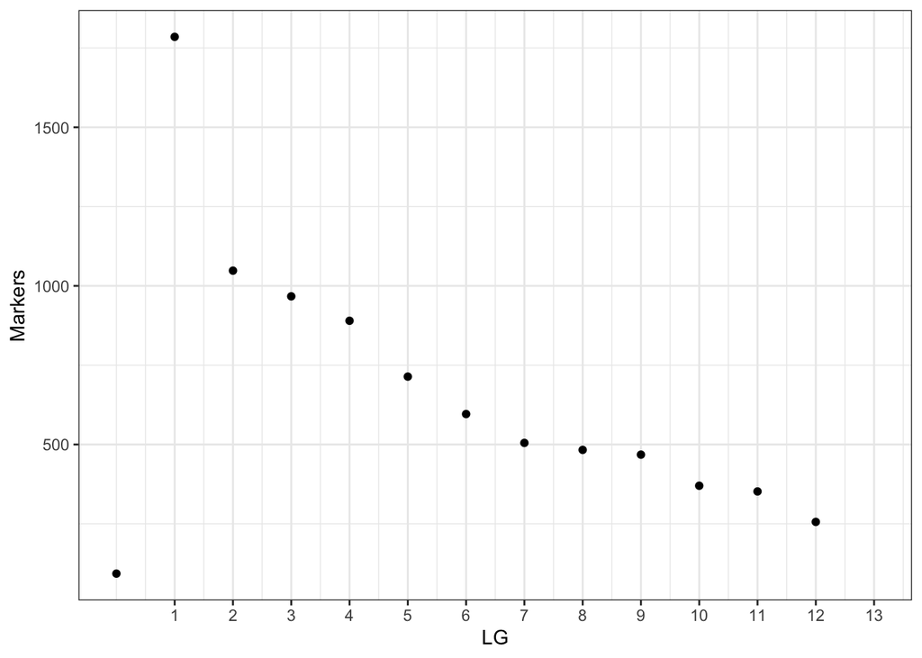

```r
ggplot(tempdf) +
  geom_point(aes(x=LG, y=Markers)) +
  scale_x_continuous(limits = c(0,13), breaks = seq(1,13,1)) +
  scale_y_continuous() +
  theme_bw()
```

Here we can clearly see that linkage group 1 has a lot more markers than the rest of the linkage groups. Now this is where linkage mapping becomes tricky, and a good knowledge of the species karyotype can help. For instance, if we knew that one chromosome was ~double the size of all others, we might take this result as a biologically true results. While if we knew that chromosomes were of similar size, we might take this as an issue with our pipeline so far.

One thing to remember although is that larger linkage groups do tend to attract loose markers and sometimes entire linkage groups.

In light of my knowledge of the species karyotype (13 chromosomes of similar size), i believe that this is the result of using a *too low lod limit*.

### 3.1. Assess multiple LOD limit values

Thus, let’s see what happens when we increase the `lodLimit` parameter. We will do so for a range of values, from 11 to 20. Given that this is now a considerable number of jobs, we will submit them with a PBS script. More specifically, we will use an array job.

```bash
#!/bin/bash

#PBS -j oe
#PBS -N lepmap.sepchrom
#PBS -l nodes=1:ppn=2
#PBS -l mem=1gb
#PBS -l walltime=05:00:00
#PBS -J 11-20

# Set directory to your project folder
# you will need to change this to match
# your folder name and path
cd ~/LinkageMapWorkshop

# Assign array index to variable
LOD=${PBS_ARRAY_INDEX}

# Run Separate chromosomes
java -cp lepmap/bin/ SeparateChromosomes2 \
  data=2_filtered/2_2_filtered_fam1_default \
  lodLimit=${LOD} sizeLimit=50 numThreads=2 > temp/tempfile3_LOD${LOD}.txt
```

Once again, copy this script, and paste into a new file called `3_sepchrom_test.sh`. Submit with `qsub`

```bash
qsub scripts/3_sepchrom_test.sh
```

Once all jobs are run, we can check their logfiles (note I have moved all logfiles into a `logfiles` folder).

```bash
for i in {11..20}
do
echo "LOD = "${i}" "`cat ../logfiles/lepmap.sepchrom.o2475361.${i} | tail -n 1`
done
```

```
## LOD = 11 Number of LGs = 13, markers in LGs = 8425, singles = 102
## LOD = 12 Number of LGs = 13, markers in LGs = 8417, singles = 110
## LOD = 13 Number of LGs = 13, markers in LGs = 8402, singles = 125
## LOD = 14 Number of LGs = 13, markers in LGs = 8370, singles = 157
## LOD = 15 Number of LGs = 13, markers in LGs = 8362, singles = 165
## LOD = 16 Number of LGs = 13, markers in LGs = 8353, singles = 174
## LOD = 17 Number of LGs = 13, markers in LGs = 8254, singles = 273
## LOD = 18 Number of LGs = 13, markers in LGs = 8180, singles = 347
## LOD = 19 Number of LGs = 13, markers in LGs = 8002, singles = 525
## LOD = 20 Number of LGs = 18, markers in LGs = 7636, singles = 891
```

Before deciding on a LOD value limit, let’s see the number of markers per LG with a LOD value of 20.

```bash
cut -f 1 ../temp/tempfile3_LOD20.txt | sort | uniq -c | sort -k2 -n | tail -n +2
```

```
##  891 0
## 1004 1
##  997 2
##  922 3
##  819 4
##  629 5
##  526 6
##  512 7
##  443 8
##  384 9
##  355 10
##  262 11
##  198 12
##  174 13
##  120 14
##  114 15
##   60 16
##   59 17
##   58 18
```

It is a pretty linear decrease, with no clear boundary between the 13th LG and the rest in terms of number of markers.

At this stage the decision of what LOD value to use is very delicate, as there is no clear *right* value to use. A lower LOD value (e.g., 11) will include more markers, which is good if your aim is to have a very dense map, but it might add erroneous markers to linkage groups (especially the larger ones). If your aim is to have a very accurate first map on the other hand, use the highest LOD score that retains the biologically correct nunmber of LG. This will give the most accurate map, but also the lower marker density.

For this workshop I will retain both the map with the lowest LOD (11) and the highest LOD (19), so we can compare the results later on. Thus, to move forward, I will create a directory to retain the map files I want to keep and copy the desired map files into that directory.

```bash
mkdir -p 3_mapfiles
```

Then copy the desired map files

```bash
for i in 11 19
do
cp temp/tempfile3_LOD${i}.txt \
  3_mapfiles/3_1_fam1_map_LOD${i}.txt
done
```

*NOTE*: In this workshop we are assuming that you know the karyotype of your species (i.e., how many chromosomes). If you do not know, you can still get a pretty confident estimate from your data given that it has low error rate and enough offspring per family. In brief, to do so, I usually run `SeparateChromosomes2` for a range of LOD values, in combination with the `sizeLimit` parameters, to assess whether there is a certain number of linkage groups that comes up consistently across many LOD value. If you are unsure of how to do this yourself, please do not hesitate to contact me on twitter (@Itsfrogday).

### 3.2. Join singles to existing linkage groups

An additional step at this stage is to add markers not assigned to any linkage group to existing linkage groups. This is a way to increase marker density (by decreasing LOD limit for a marker to be added with `JoinSingles2All`) while ensuring that the biologically correct number of linkage group is used (by having a high LOD value for `SeparateChromosomes2`).

For this example data we won’t be doing this, as the number of not-assigned markers is pretty low. But, if you want to do it for your data, you should use the following code:

```bash
java -cp lepmap/bin/ JoinSingles2All \
# Use same data as that used for SeparateChromosomes
  data=2_filtered/2_2_filtered_fam1_default \
# Define the map file produced by SeparateChromosomes
  map=3_mapfiles/3_1_fam1_map_LOD11.txt \
# Define LOD limit for a marker to be added
# This should be lower than what you used to identify LGs
  lodLimit=10 \
# Define the difference in LOD value for marker matching two LGs
# below which the marker is not added
  lodDifference=2 > 3_mapfiles/3_2_fam1_map_LOD11_joinsingles.txt
```

Note, these are only some of the parameters that can be used. Call the `JoinSingles2All` module without any input to see the other parameters.

## 4. Order markers

Now that we have assigned markers to linkage groups, it is time to order the markers along the linkage groups using the `OrderMarkers2` module from LepMap.

This module has a lot of parameters and options. For today we will mostly focus on a few key ones, as per the below script (note: do not run).

```bash
java -cp lepmap/bin OrderMarkers2 data=filteredData map=map.txt \
  # Select whether to include markers with informative father (1), mother (2) or both parents (3).
  informativeMask=NUM \
  # Select linkage group to analyse
  chromosome=NUM \
  # Select number of threads
  numThreads=NUM \
  # Calculate sex-averaged map distances
  sexAveraged=1 \
  # Compute and output pair wise LOD scores
  computeLODscores=file
  # Calculate distance between markers in cM
  calculateIntervals=file
```

These main parameter include the input data file we previously filtered with the `Filtering2` module (e.g., *2_2_filtered_fam1_default*); the map file produced by `SeparateChromosomes2`, which contains the linkage group to which each marker was assigned (e.g. *3_1_fam1_map_LOD11.txt*), and then a set of parameters.

The `informativeMask` can be used to produce the father and mother specific linkage maps (i.e., using only markers that contain information about recombination event for that parent). This can be useful to assess differential recombination between the sexes, and for troubleshooting. I usually always produce male and female specific linkage maps.

LepMap also offers the option to output the sexaveraged linkage map (i.e., the average position in centimorgans between the two sex-specific maps). We will skip this as we can easily calculate it later ourselves.

The computeLODscores and calculateIntervals files can be useful for troubleshooting (i.e., identifying markers that might have been misplaced) and for producing summary statistics (e.g., the average intermarker distance). We most likely will not use these two during the workshop, but I thought it was important to point them out.

Now that we now what is required, we can start preparing some linkage maps. As recommended by the authors of LepMap, the `OrderMarkers2` module should be run multiple times for each linkage group, then selecting the order with the highest likelihood.

### 4.1. Order Markers first run

Let’s thus make a script that will run the module separately for each linkage group with five replicates for each linkage group.

First we will need a file with all the set of parameters we want to run (i.e., 13 linkage groups, 5 replicates -> 65 different parameters sets). This will make our life easier when submitting the job as an array.

```bash
if [ ! -f par.file ]
then
    for LG in {1..13}
    do
      for REP in a b c d e
      do
      newline=${LG}"\t"${REP}
      echo -e $newline >> par.file
      done
    done
else
    echo "File already exists"
fi
```

The resulting parameter file looks like this:

```bash
cat ../par.file | head
```

```
## 1    a
## 1    b
## 1    c
## 1    d
## 1    e
## 2    a
## 2    b
## 2    c
## 2    d
## 2    e
```

Now we can build our script:

```bash
#!/bin/bash

#PBS -j oe
#PBS -N lepmap.order
#PBS -l nodes=1:ppn=2
#PBS -l mem=1gb
#PBS -l walltime=50:00:00
#PBS -J 1-65

# Set directory to your project folder
# you will need to change this to match
# your folder name and path
cd ~/LinkageMapWorkshop

##### Obtain parameters from par file #####
parameters=`sed -n "${PBS_ARRAY_INDEX} p" par.file`
# turn parameters into array
parameterArray=($parameters)
# assign elements of array to two variables, Linkage Group and REPlicate
LG=${parameterArray[0]}
REP=${parameterArray[1]}

# Run Order chromosomes for female map
java -cp lepmap/bin/ OrderMarkers2 \
  data=2_filtered/2_2_filtered_fam1_default \
  map=3_mapfiles/3_1_fam1_map_LOD11.txt \
  numThreads=2 \
  chromosome=${LG} informativeMask=23 > 4_orderedMarkers/4_1_fam1_Female_LG${LG}_REP${REP}

# Run Order chromosomes for male map
java -cp lepmap/bin/ OrderMarkers2 \
  data=2_filtered/2_2_filtered_fam1_default \
  map=3_mapfiles/3_1_fam1_map_LOD11.txt \
  numThreads=2 \
  chromosome=${LG} informativeMask=13 > 4_orderedMarkers/4_1_fam1_Male_LG${LG}_REP${REP}
```

Note that we are saving the results in a folder called `4_orderedMarkers`. Make sure to create the folder first.

```bash
mkdir -p 4_orderedMarkers
```

Then, like we did before, copy the script in the code chunk above, and past it into a new text file called `4_orderMarkers_1.sh` within Visual Studio Code, in the `scripts` directory.

And finally submit it. Especially for larger families (and especially in the HPC with all these people using it), this step will take a while.

```bash
qsub scripts/4_orderMarkers_1.sh
```

Once all the jobs have run, we can check the logfiles for errors.

```bash
grep -E "e:|error|killed" logfiles/lepmap.order.*
```

```
## ../logfiles/lepmap.order.024754771.error:=>> PBS: job killed: mem 10555244kb exceeded limit 10485760kb
```

Here for instance we can see that one job from the array got killed because it was using too much memory. We can check which one it was.

```bash
grep -lE "e:|error|killed" logfiles/lepmap.order.*
```

```
## ../logfiles/lepmap.order.024754771.error
```

### 4.2. Select highest likelihood run

To select the highest likelihood run, I use the below script. It has two loops, one per sex.

```bash
#!/bin/bash
for LG in {1..13} ; do
  for REP in {a..e} ; do
    echo -n "$LG ${REP} " >> "4_2_fam1_Female_LIK.txt"
    echo | sed '2q;d' "4_1_fam1_Female_LG${LG}_REP${REP}" | awk '{print $7}' >> "4_2_fam1_Female_LIK.txt"
  done
done

for LG in {1..13} ; do
  for REP in {a..e} ; do
    echo -n "$LG ${REP} " >> "4_2_fam1_Male_LIK.txt"
    echo | sed '2q;d' "4_1_fam1_Male_LG${LG}_REP${REP}" | awk '{print $7}' >> "4_2_fam1_Male_LIK.txt"
  done
done
```

Copy the above script and paste into a file in the `4_orderedMarkers` folder called `4_2_extractLikelihood.sh`.

From that folder, make the script executable with:

```bash
chmod +x 4_2_extractLikelihood.sh
```

And then run it

```bash
./4_2_extractLikelihood.sh
```

The resulting files for each sex will look like this:

```bash
cat 4_orderedMarkers/4_2_fam1_Female_LIK.txt | head
```

```
## 1 a -28947.0869
## 1 b -28977.749
## 1 c -28922.988
## 1 d -28919.7422
## 1 e -28983.8897
## 2 a -27827.2326
## 2 b -27910.4653
## 2 c -27831.7311
## 2 d -27828.8141
## 2 e -27915.6352
```

Let’s import it as a dataframe so we can plot likelihoods and select best run for each linkage group.

```r
fam1_LIK_fem <- read_delim("../4_orderedMarkers/4_2_fam1_Female_LIK.txt",
                      delim = " ",
                      col_names = c("LG","ITE","LIK"))

fam1_LIK_male <- read_delim("../4_orderedMarkers/4_2_fam1_Male_LIK.txt",
                      delim = " ",
                      col_names = c("LG","ITE","LIK"))
```

Plot the likelihoods

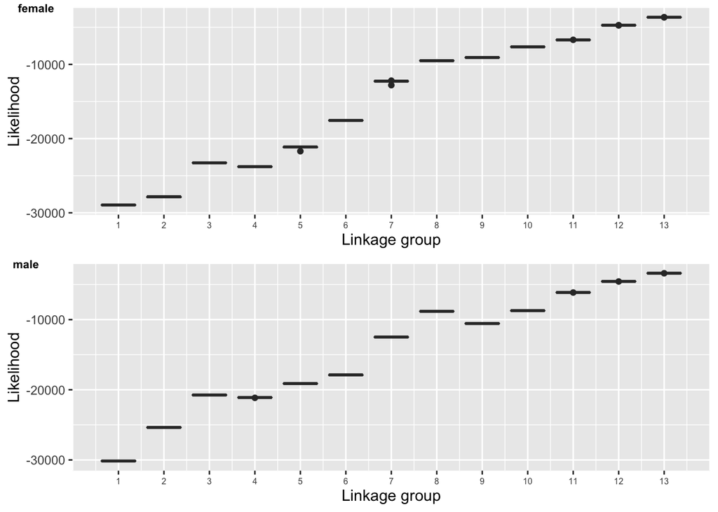

```r
p1 <- ggplot(fam1_LIK_fem, aes(x = LG, y = LIK, group = LG)) +
  geom_boxplot() +
  #adjust based on your number of linkage groups
  scale_x_continuous(breaks = seq(1,13,1)) +
  ylab("Likelihood") + xlab("Linkage group") +
  theme(axis.text.x = element_text(size=6))


p2 <- ggplot(fam1_LIK_male, aes(x = LG, y = LIK, group = LG)) +
  geom_boxplot() +
  #adjust based on your number of linkage groups
  scale_x_continuous(breaks = seq(1,13,1)) +
  ylab("Likelihood") + xlab("Linkage group") +
  theme(axis.text.x = element_text(size=6))

ggarrange(p1,p2,
          ncol = 1, nrow = 2, align = "hv",
          labels = c("female","male"),
          font.label = list(size = 8))
```

In the above plot, we have linkage groups on the x axis, and likelihood on the y axis, with values from the female map on top and the male map on the bottom panel.

We can see some patterns: - Smaller linkage groups have higher likelihoods. This is a direct result of them having less markers and is to be expected - There is little variation in likelihood within linkage group. This is a rudimental indication of ‘convergence’ (not a statistician, sorry if i’m butchering/misusing this term). That means that regardless of what path the algorithm follows for ordering the markers, the result is mostly the same.

Nevertheless, let’s extract the replicate for each linkage group with the highest likelihood, and save them all for a file, one per sex.

```r
fam1_best_fem <- fam1_LIK_fem %>% group_by(LG) %>%
  slice_max(n=1, order_by=LIK, with_ties=FALSE) %>%
  select(LG, ITE) %>% unite("Best", remove = TRUE, sep = "_")

fam1_best_male <- fam1_LIK_male %>% group_by(LG) %>%
  slice_max(n=1, order_by=LIK, with_ties=FALSE) %>%
  select(LG, ITE) %>% unite("Best", remove = TRUE, sep = "_")

write_delim(fam1_best_fem,
            file = "../4_orderedMarkers/4_3_fam1_female_Best.txt",
            delim = "\t", col_names = FALSE)

write_delim(fam1_best_male,
            file = "../4_orderedMarkers/4_3_fam1_male_Best.txt",
            delim = "\t", col_names = FALSE)
```

Now, to make evaluating, plotting and assessing maps easier we will copy the maps with the best likelihoods and rename them with the below script

```bash
#!/bin/bash

#loop through rows of file containing best run info
while read p; do
  #select LG from row
  LG=`awk -F'[_]' '{print $1}' <<< "$p"`
  #select REP id from row
  REP=`awk -F'[_]' '{print $2}' <<< "$p"`
  #copy and rename the files for the best run for each LG
  cp "4_1_fam1_Female_LG${LG}_REP${REP}" "4_4_fam1_female_LG${LG}"
done < "4_3_fam1_female_Best.txt"

#loop through rows of file containing best run info
while read p; do
  #select LG from row
  LG=`awk -F'[_]' '{print $1}' <<< "$p"`
  #select REP id from row
  REP=`awk -F'[_]' '{print $2}' <<< "$p"`
  #copy and rename the files for the best run for each LG
  cp "4_1_fam1_Male_LG${LG}_REP${REP}" "4_4_fam1_male_LG${LG}"
done < "4_3_fam1_male_Best.txt"
```

Save this as a script called `4_4_moveBest.sh` into the `4_orderedMarkers` directory.

Now we have the a map file for each of the linkage group, selected based on likelihood.

### 4.3. Import and format maps

Let’s look at what one of the files output by `OrderMarkers2`.

```bash
cat ../4_orderedMarkers/4_4_fam1_male_LG13 | head
```

```
## #java OrderMarkers2 data=2_filtered/2_2_filtered_fam1_default map=3_mapfiles/3_1_fam1_map_LOD11.txt numThreads=2 chromosome=13 informativeMask=13 randSeed=3629432373075994576
## #*** LG = 13 likelihood = -3386.8504
## #marker_number   male_position   female_position ( parental_phase )[ phased data]
## 1091 0.000   0.000   ( CA,AC )   101110111111011010000011101011000110110001111010001010101111… 0 0
## 5354 0.000   0.000   ( CA,-- )   101110111111011010000011101011000110110001111010001010101111… 0 0
## 1529 2.308   0.000   ( CA,AC )   101110111111011010000011101011000110110001111010001010101111… 3 0
## 7196 2.308   0.000   ( CA,-- )   101110111111011010000011101011000110110001111010001010101111… 0 0
## 1530 2.308   0.000   ( CA,AC )   101110111111011010000011101011000110110001111010001010101111… 0 0
## 2897 3.066   0.758   ( CA,-- )   101110111111011010000011101011000110110001111010001010101111… 1 1
## 1580 11.214  0.758   ( AC,CA )   101110110111011001000011100010000110110001111010011010101111… 10 0
```

The first row shows the command invoked to produce the file, the second shows the likelihood for this map for this linkage group and the third contains column names. From here onwards, each row represents one marker, with the columns being, as the names suggest, the marker number, the position in the male map, the poisition in the female map, the parental phase and then the phased data.

The marker number represents the row in which that marker was located in the file produced with the `Filtering2` module.

Let’s thus gather all of this data in a single data frame, so that we can start plotting it and assessing our maps.

First for the male maps:

```r
# make list of file names for files containing map data - e.g., 4_4_fam1_male_LG1
maps.male <- list.files(path = "../4_orderedMarkers",
                  pattern = glob2rx(pattern="4_4_fam1_male_LG*"),
                  full.names = TRUE)

# name each file according to the linkage group it belongs to
names(maps.male) <- c("1","10","11","12","13","2","3",
                "4","5","6","7","8","9")

# this lapply loop reads the individual tab-delimited files into a list
maps.male <- lapply(maps.male, function(m) {
    read_delim(m, delim = "\t",
               skip = 4,
               col_names = c("ID","male","female"))
})

# this mapply loops iterates over the list of dataframes from the previous step and their LG numbers
# it adds a column to each dataframe containing info on the LG number
maps.male <- mapply(function(z,w) {
  z <- z %>% select(ID,male,female)

  z %>% mutate("LG" = w)
}, maps.male, names(maps.male), SIMPLIFY = FALSE)

# now that each dataframe has data on map position, SNPID and LG, we can bind them all together for each family
maps.male <- do.call("rbind", maps.male)
```

Then for the female map

```r
# make list of file names for files containing map data - e.g., 4_4_fam1_male_LG1
maps.female <- list.files(path = "../4_orderedMarkers",
                  pattern = glob2rx(pattern="4_4_fam1_female_LG*"),
                  full.names = TRUE)

# name each file according to the linkage group it belongs to
names(maps.female) <- c("1","10","11","12","13","2","3",
                "4","5","6","7","8","9")

# this lapply loop reads the individual tab-delimited files into a list
maps.female <- lapply(maps.female, function(m) {
    read_delim(m, delim = "\t",
               skip = 4,
               col_names = c("ID","male","female"))
})

# this mapply loops iterates over the list of dataframes from the previous step and their LG numbers
# it adds a column to each dataframe containing info on the LG number
maps.female <- mapply(function(z,w) {
  z <- z %>% select(ID, male, female)
  z %>% mutate("LG" = w)
}, maps.female, names(maps.female), SIMPLIFY = FALSE)

# now that each dataframe has data on map position, SNPID and LG, we can bind them all together for each family
maps.female <- do.call("rbind", maps.female)
```

This is what the resulting dataframe should look like:

```r
head(maps.male)
```

```
## # A tibble: 6 × 4
##      ID  male female LG
##   <dbl> <dbl>  <dbl> <chr>
## 1  1887  0     0     1
## 2  1237  1.53  0     1
## 3  2173  4.63  0.758 1
## 4  2172  4.63  0.758 1
## 5  2175  4.63  0.758 1
## 6  1382  8.54  0.758 1
```

Let’s full_join these two, retaining only the sex specific map we requested each time.

```r
X <- maps.female %>% select(ID,LG,female)
Y <- maps.male %>% select(ID,LG,male)

maps <- full_join(X, Y, by = c("ID","LG"),
                 keep = FALSE)

rm(maps.female, maps.male, X, Y)
```

Unfortunately (and annoyingly) LepMap converts marker IDs to sequential numbers. Let’s retrieve the original marker IDs from the `Filtering2` output.

```r
# read Filtering2 output
snpids <- read_delim("../2_filtered/2_2_filtered_fam1_default",
                delim = "\t",skip = 7,
                col_names = "SNPID")
# add column with sequential ids from 1 to nrow
snpids <- snpids %>% add_column("ID" = seq(1:nrow(snpids)))
```

Producing this file:

```r
head(snpids)
```

```
## # A tibble: 6 × 2
##   SNPID    ID
##   <chr> <int>
## 1 5_27      1
## 2 14_29     2
## 3 53_19     3
## 4 54_52     4
## 5 55_14     5
## 6 59_9      6
```

The first column represent the snpids you provided when you started using lepmap, the ID column represent the sequential numerical IDs that lepmap uses instead. Now we can add the original IDs to our maps.

```r
#join
maps <- left_join(maps, snpids, by="ID")

#re-arrange
maps <- maps %>% select(SNPID, ID, LG, male, female)
```

```r
#create emtpy tibble
temp <- tibble(
  SNPID = character(),
  ID = double(),
  LG = factor(),
  male = double(),
  female = double()
  )

#loop through linkage groups
for (i in 1:13) {
  #retain one linkage group
  y <- maps %>% filter(LG == i)
  #find max value for female linkage map
  my.max <- max(y$female, na.rm = TRUE)

  #if covariance is negative (inversely correlated)
  if (cov(y$male, y$female,
          use = "pairwise.complete.obs") < 0) {
    #modify female map to be inverted
    z <- y %>%
      mutate(female = case_when(
        female >= 0 ~ (my.max-female),
        TRUE ~ female
        ))
    #add to dataframe
    temp <- bind_rows(temp,z)
    }
  #if covariance is positive
  else {
    #bind orignal non-modified dataframe
    temp <- bind_rows(temp,y)
  }
}

#rename
old.maps <- maps
maps <- temp

#remove unnecessary intermediate files
rm(temp,y,z,i,my.max)
```

This step was a bit rushed (sorry i’m running out of time preparing this workshop). But don’t worry, we get the non-inverted maps, and the reason for this step will become clearer once we plot the maps.

Finally, let’s save these, both as tab-delimited files. We will do so in a new folder called `5_maps`

```r
write_delim(maps, file = "../5_maps/5_1_fam1_linkageMap.txt",
            delim = "\t",col_names = T)
```

### 4.4. Plot male versus female maps

A very good way to both assess the quality of a map, troubleshoot, and gain the first biological insights for your species is to plot the male and female maps against each other.

First, let’s do one final tidy up

```r
old.maps <- old.maps %>% mutate(LG = fct_relevel(LG, "1", "2", "3", "4", "5", "6", "7", "8", "9", "10", "11", "12", "13"))

maps <- maps %>% mutate(LG = fct_relevel(LG, "1", "2", "3", "4", "5", "6", "7", "8", "9", "10", "11", "12", "13"))
```

And then plot the maps

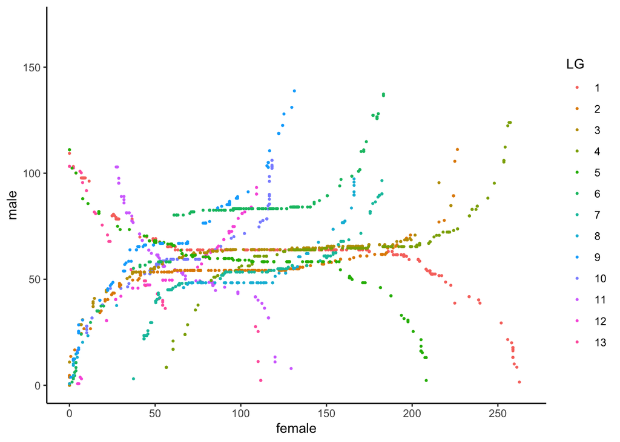

```r
p1 <- ggplot(old.maps,
             aes(x=female, y=male,
                 group = LG, colour = LG)) +
  geom_point(size=0.5) + theme_classic() +
  scale_y_continuous(limits = c(0, 170),
                     breaks = seq(0, 150, by = 50)) +
  scale_x_continuous(limits = c(0,265),
                     breaks = seq(0, 250, by = 50))

p1
```

Wow, this looks messy! Lorenzo must have made a mistake somewhere. Can you see what might be going on? This map is the one where we did not match the male and female maps As in, the start for some of the male maps, is the end in the respective female map. So, let’s plot the same data adjusted for this issue (we produced this before)

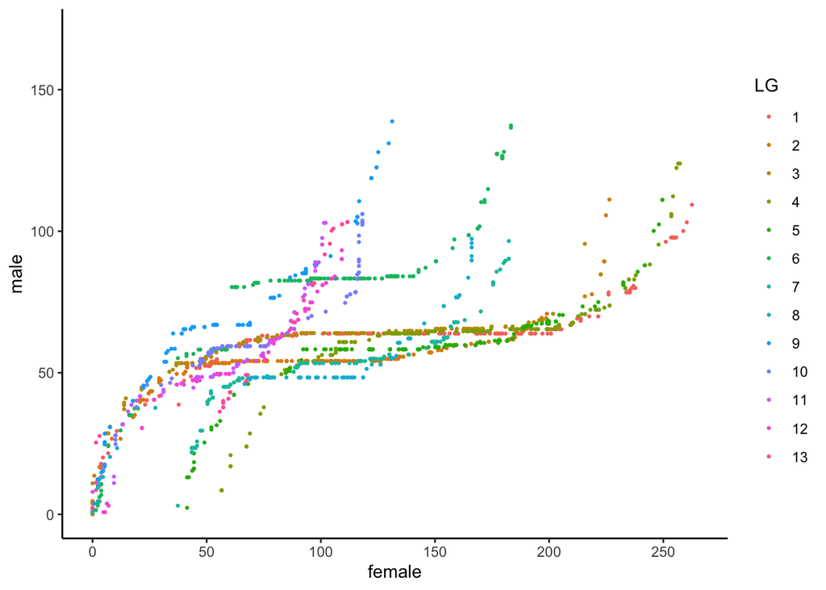

```r
p2 <- ggplot(maps,
             aes(x=female, y=male,
                 group = LG, colour = LG)) +
  geom_point(size=0.5) + theme_classic() +
  scale_y_continuous(limits = c(0, 170),
                     breaks = seq(0, 150, by = 50)) +
  scale_x_continuous(limits = c(0,265),
                     breaks = seq(0, 250, by = 50))

p2
```

Now this is starting to look a bit more tidy. Let’s try and interpret it. On the x-axis we have the position for the marker on the female linkage map. On the y-axis we have instead the position on the male map.

Now, a basic assumption is that markers should mainly have the same order in the genome of the female and male parent, thus we would expect a 1:1 relationship.

But! Here we are not mapping position directly, but position as it can be inferred frmo recombination rates! Importantly, recombination rates differ between sexes, and thus we obtain this S-shaped relationship. Let’s look at the map for a single linkage group.

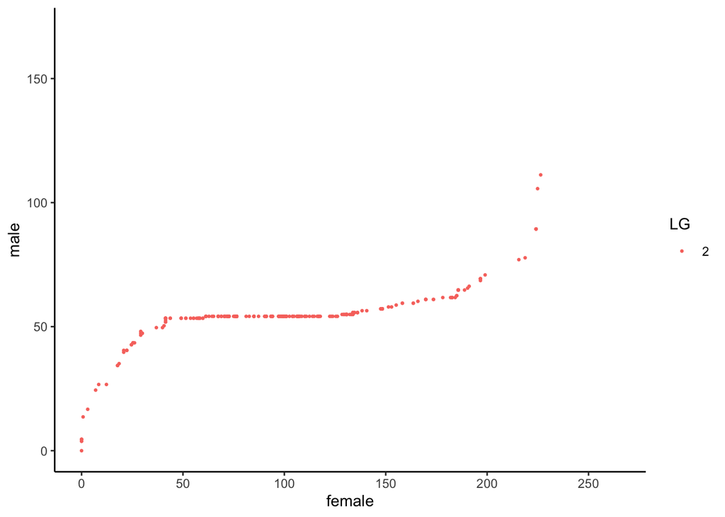

```r
p3 <- ggplot(maps %>% filter(LG==2),
             aes(x=female, y=male,
                 group = LG, colour = LG)) +
  geom_point(size=0.5) + theme_classic() +
  scale_y_continuous(limits = c(0, 170),
                     breaks = seq(0, 150, by = 50)) +
  scale_x_continuous(limits = c(0,265),
                     breaks = seq(0, 250, by = 50))

p3
```

Now this relationship is a bit clearer. What can we gather from this plot?

1. The female experiences overall more recombination than the male (in this species). This is highlighted by the longer length for the female map for LG2.
2. A lot of markers in the male map are placed within the same position (~50-55 cM). This is likely because of a very low recombination rate towards the centre of the chromosome in the male.

In frogs, this difference in recombination is the result of chiasmata forming evenly across the chromosomes in biological females, while in biological males they form mostly around the ends of the chromosomes.

Okay, now that we are starting to understand this better, let’s plot all linkage groups individually and see if we can spot anything else.

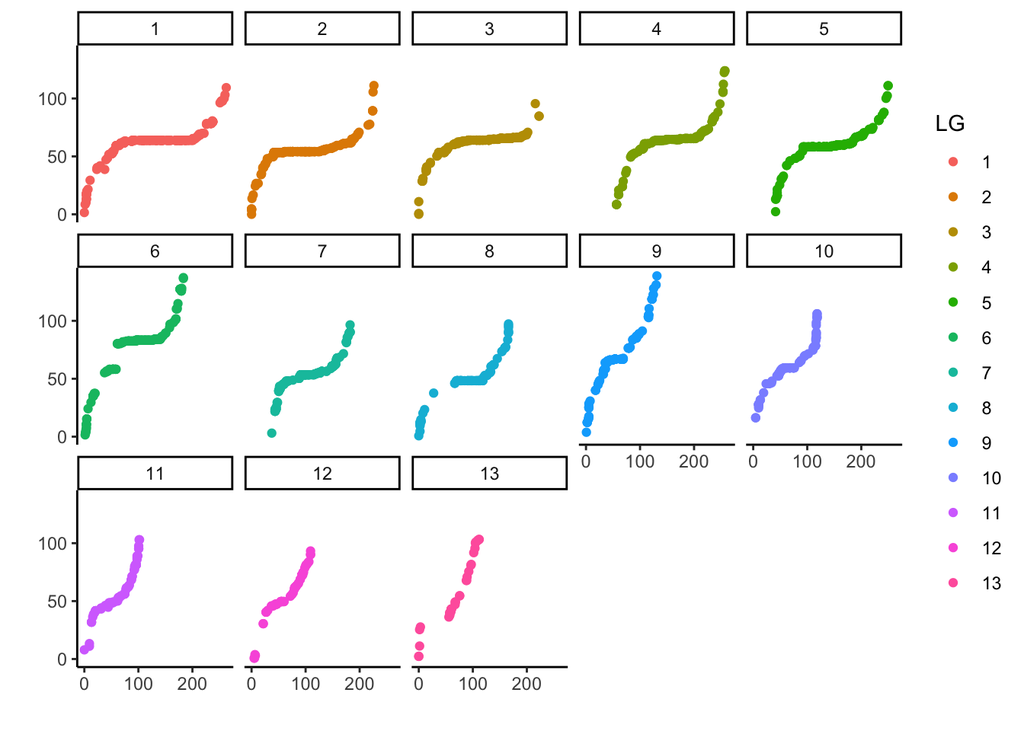

```r
# Remove any row with NAs
# these are the rows that include markers mapped only in the male or female map
# Thus, we will only be mapping markers heterozygous for both parents
maps.NA <- maps %>% drop_na()

# Plot the resulting data
p4 <- ggplot(maps.NA, aes(x=female, y=male,
                          group = LG, colour = LG)) +
  #facet by Linkage group
  geom_point() + facet_wrap(~LG, ncol = 5) +
  ylab("") + xlab("") +
  theme(strip.background = element_blank(),
        strip.text.x = element_blank()) +
  theme_classic()

p4
```

### 4.5. Identify erroneous markers

Okay, we’ve produced some beautiful rainbow worms. We know that because of the S-shape of these worms, recombination rate is heterogenous within and across the two sexes. But that’s not the only thing. These S-shapes can start to show some things that might have not worked.Can you spot them?

It’s okay if you haven’t. Let’s try and plot each sex separately, and see whether the issue becomes evident. I am going to be cheating now and select a certain linkage group. Linkage group 4. Have you spotted the issue yet?

Don’t worry, soon. First we plot male vs female LG4

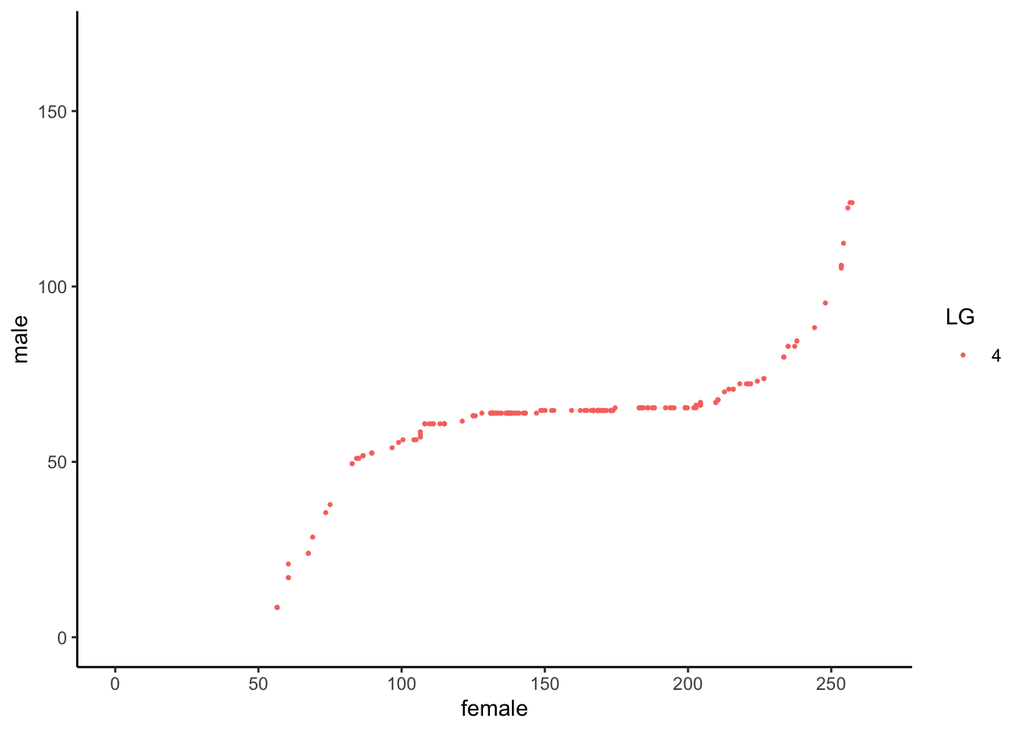

```r
p5 <- ggplot(maps %>% filter(LG==4),
             aes(x=female, y=male,
                 group = LG, colour = LG)) +
  geom_point(size=0.5) + theme_classic() +
  scale_y_continuous(limits = c(0, 170),
                     breaks = seq(0, 150, by = 50)) +
  scale_x_continuous(limits = c(0,265),
                     breaks = seq(0, 250, by = 50))

p5
```

Mmm, something insteresting here do you agree? The female map seems to start frmo 50 centimorgans. This results in the S shape being shifted a bit to the right. At the moment we are plotting only double heterozygous markers. To find the culprit we will have to plot uni-parental (i.e., heterozygous in one parent only) markers. To achieve this we will do a little trick, of plotting the map position in one sex against sequential integers.

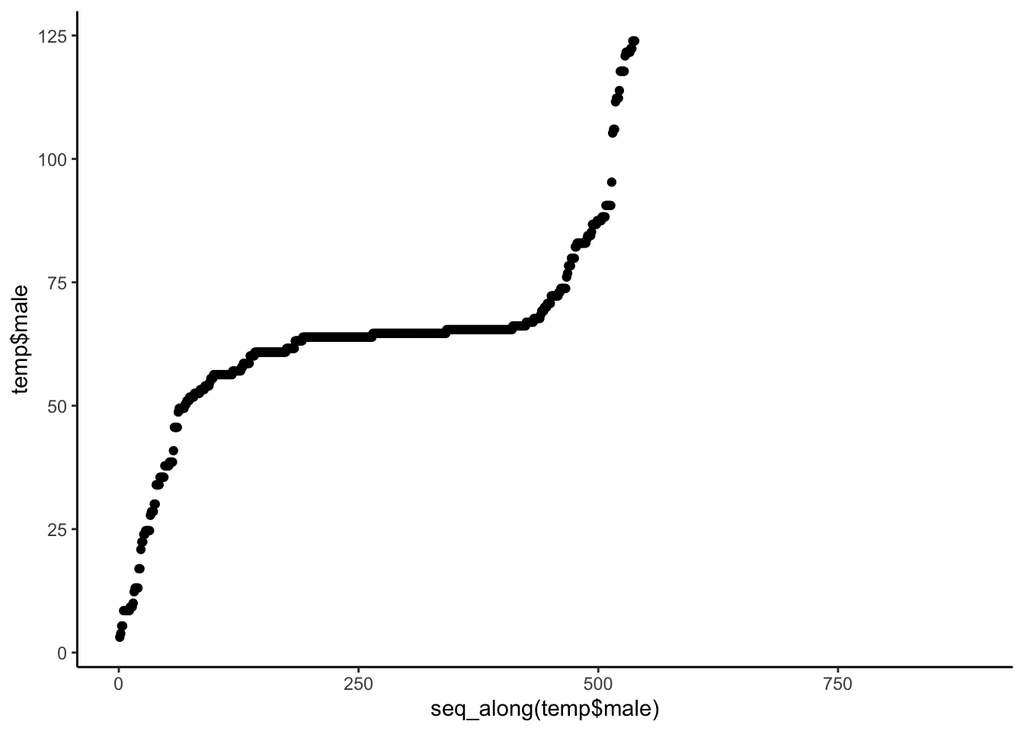

```r
temp <- maps %>% filter(LG == 4) %>% arrange(male)

qplot(seq_along(temp$male), temp$male) +
  theme_classic()
```

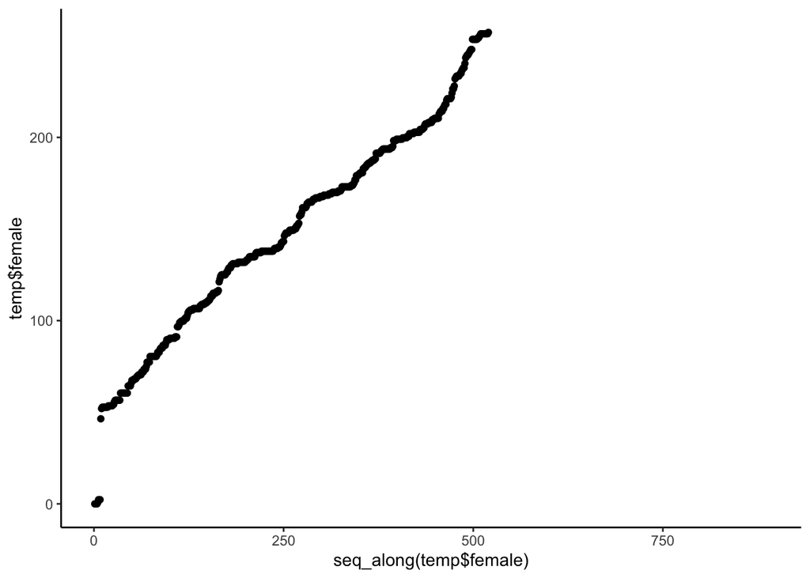

```r
temp <- maps %>% filter(LG == 4) %>% arrange(female)

qplot(seq_along(temp$female), temp$female) +
  theme_classic()
```

```r
maps %>% filter(LG==4) %>% arrange(female) %>% head(n=20)
```

```
## # A tibble: 20 × 5
##    SNPID        ID LG     male female
##    <chr>     <dbl> <fct> <dbl>  <dbl>
##  1 209399_41  8464 4        NA  0
##  2 209399_6   8459 4        NA  0
##  3 209399_14  8461 4        NA  0
##  4 209399_12  8460 4        NA  0
##  5 209399_17  8462 4        NA  0.758
##  6 209399_46  8465 4        NA  2.28
##  7 209399_39  8463 4        NA  2.28
##  8 209399_53  8467 4        NA  2.28
##  9 29088_6    1281 4        NA 46.4
## 10 194520_33  8427 4        NA 52.0
## 11 51588_57   8115 4        NA 52.8
## 12 51588_38   8114 4        NA 52.8
## 13 115548_59  8330 4        NA 52.8
## 14 39326_39   7260 4        NA 52.8
## 15 34343_34   6740 4        NA 52.8
## 16 40484_21   7404 4        NA 52.8
## 17 40484_22   7405 4        NA 52.8
## 18 39326_62   7261 4        NA 52.8
## 19 1144_13    2221 4        NA 53.5
## 20 28783_19   6095 4        NA 53.5
```

Thus, one key step when polishing and assessing the quality of your maps should be to investigate each linkage group, looking for any group of ~1-2 loci that cause gaps longer than 10-15 cM at the end of the LG.

What to do next? Well, now that we now what markers are erroneous, we can exclude them from the linkage map and re-run the `OrderMarkers2` module. There are many ways to do this, and I encourage you to find what works best for you. Now I will show you how I have been doing it (fully aware that it is a bit clunky).

The first step is to produce a new map file where the unwanted markers are assigned to LG 0. So, let’s re-read the list of snpids, as well as the map file used for the OrderMarkers2 step (either the output of SeparateChromosomes2 or JoinSingles2All).

Read in map file

```r
mapfile <- read_delim("../3_mapfiles/3_1_fam1_map_LOD11.txt", col_names = "LG", skip = 1, delim="\t")
```

The list of snpids can be obtained from the genotype file used as the `data` input for OrderMarkers2 (i.e., the output of the Filtering2 module).

```r
# read Filtering2 output
snpids <- read_delim(
  "../2_filtered/2_2_filtered_fam1_default",
                delim = "\t",skip = 7,
                col_names = "SNPID")
# add column with sequential ids from 1 to nrow
snpids <- snpids %>% add_column("ID" = seq(1:nrow(snpids)))
```

Now we can merge the snpids and mapfile dataframes.

```r
mapfile <- tibble("markerID"=snpids$SNPID,
                  "LG"=mapfile$LG)
```

To produce the following output:

```r
head(mapfile)
```

```
## # A tibble: 6 × 2
##   markerID    LG
##   <chr>    <dbl>
## 1 5_27         7
## 2 14_29        3
## 3 53_19        1
## 4 54_52        1
## 5 55_14        1
## 6 59_9         2
```

Now we want to change the value of LG to 0 for those markers we identified on locus 209399.

```r
mapfile2 <- mapfile %>%
  mutate(LG = case_when(
    markerID == "209399_6" ~ 0,
    markerID == "209399_12" ~ 0,
    markerID == "209399_14" ~ 0,
    markerID == "209399_17" ~ 0,
    markerID == "209399_39" ~ 0,
    markerID == "209399_41" ~ 0,
    markerID == "209399_46" ~ 0,
    markerID == "209399_53" ~ 0,
    TRUE ~ LG))
```

To check it worked we can compare number of markers in LG for the two dataframes.

```r
table(mapfile$LG)
```

```
##
##    0    1    2    3    4    5    6    7    8    9   10   11   12   13
##  102 1046 1022  962  889  763  714  596  505  482  468  370  352  256
```

```r
table(mapfile2$LG)
```

```
##
##    0    1    2    3    4    5    6    7    8    9   10   11   12   13
##  110 1046 1022  962  881  763  714  596  505  482  468  370  352  256
```

Good, LG four has 8 less markers assigned. Now let’s save the LG column of mapfile2 as a textfile to be used as a mapfile for re-running OrderMarkers2.

```r
write_delim(as.data.frame(mapfile2$LG),
            file = "../6_reorder/6_1_fam1_map_LOD11.txt",
            delim = "\t",
            col_names = FALSE)
```

The resulting file has 1 column, with no header, containing the LG each marker in the input file for OrderMarkers is assigned to.

Now we can re-run the `OrderMarkers2` module with the new map file. Here I do so only for LG4 and with one replicate, to highlight how this work. For your project you should run multiple replicates, and you might have to run multiple LGs as well. If that’s the case, simply replicate the array job we used for the first run of OrderMarkers.

```bash
#!/bin/bash

#PBS -j oe
#PBS -N lepmap.order
#PBS -l nodes=1:ppn=2
#PBS -l mem=15gb
#PBS -l walltime=10:00:00

# Set directory to your project folder
# you will need to change this to match
# your folder name and path
cd ~/LinkageMapWorkshop

##### Obtain parameters from par file #####
#parameters=`sed -n "${PBS_ARRAY_INDEX} p" par.file`
# turn parameters into array
#parameterArray=($parameters)
# assign elements of array to two variables, Linkage Group and REPlicate
#LG=${parameterArray[0]}
#REP=${parameterArray[1]}

# Run Order chromosomes for female map
java -cp lepmap/bin/ OrderMarkers2 \
  data=2_filtered/2_2_filtered_fam1_default \
  map=6_reorder/6_1_fam1_map_LOD11.txt \
  numThreads=2 \
  chromosome=4 informativeMask=23 > 6_reorder/6_1_fam1_Female_LG4_REPa

# Run Order chromosomes for male map
java -cp lepmap/bin/ OrderMarkers2 \
  data=2_filtered/2_2_filtered_fam1_default \
  map=6_reorder/6_1_fam1_map_LOD11.txt \
  numThreads=2 \
  chromosome=4 informativeMask=13 > 6_reorder/6_1_fam1_Male_LG4_REPa
```

While we wait for this to be done, I just wanted to point out that `OrderMarkers2` now includes an argument to exclude certain markers. For a few markers (e.g., < 5-10), this might be easier than the method I just showed, but if you are removing 10s of markers ‘silencing’ them from the map file might be easier.

Once the new files finished running, we can import them as we did before.

First for the male maps:

```r
# make list of file names for files containing map data -
maps.male <- list.files(path = "../6_reorder",
                  pattern = glob2rx(pattern="6_1_fam1_Male_LG*"),
                  full.names = TRUE)

# name each file according to the linkage group it belongs to
names(maps.male) <- c("4")

# this lapply loop reads the individual tab-delimited files into a list
maps.male <- lapply(maps.male, function(m) {
    read_delim(m, delim = "\t",
               skip = 4,
               col_names = c("ID","male","female"))
})

# this mapply loops iterates over the list of dataframes from the previous step and their LG numbers
# it adds a column to each dataframe containing info on the LG number
maps.male <- mapply(function(z,w) {
  z <- z %>% select(ID,male,female)

  z %>% mutate("LG" = w)
}, maps.male, names(maps.male), SIMPLIFY = FALSE)

# now that each dataframe has data on map position, SNPID and LG, we can bind them all together for each family
maps.male <- do.call("rbind", maps.male)
```

Then for the female map

```r
# make list of file names for files containing map data -
maps.female <- list.files(path = "../6_reorder",
                  pattern = glob2rx(pattern="6_1_fam1_Female_LG*"),
                  full.names = TRUE)

# name each file according to the linkage group it belongs to
names(maps.female) <- c("4")

# this lapply loop reads the individual tab-delimited files into a list
maps.female <- lapply(maps.female, function(m) {
    read_delim(m, delim = "\t",
               skip = 4,
               col_names = c("ID","male","female"))
})

# this mapply loops iterates over the list of dataframes from the previous step and their LG numbers
# it adds a column to each dataframe containing info on the LG number
maps.female <- mapply(function(z,w) {
  z <- z %>% select(ID, male, female)
  z %>% mutate("LG" = w)
}, maps.female, names(maps.female), SIMPLIFY = FALSE)

# now that each dataframe has data on map position, SNPID and LG, we can bind them all together for each family
maps.female <- do.call("rbind", maps.female)
```

Let’s full_join these two, retaining only the sex specific map we requested each time.

```r
X <- maps.female %>% select(ID,LG,female)
Y <- maps.male %>% select(ID,LG,male)

maps.2 <- full_join(X, Y, by = c("ID","LG"),
                 keep = FALSE)

rm(maps.female, maps.male, X, Y)
```

Now we can add the original IDs to our maps.

```r
#join
maps.2 <- left_join(maps.2, snpids, by="ID")

#re-arrange
maps.2 <- maps.2 %>% select(SNPID, ID, LG, male, female)
```

Now invert LGs if needed like before.

```r
#create emtpy tibble
temp <- tibble(
  SNPID = character(),
  ID = double(),
  LG = factor(),
  male = double(),
  female = double()
  )

#loop through linkage groups
for (i in 4) {
  #retain one linkage group
  y <- maps.2 %>% filter(LG == i)
  #find max value for female linkage map
  my.max <- max(y$female, na.rm = TRUE)

  #if covariance is negative (inversely correlated)
  if (cov(y$male, y$female,
          use = "pairwise.complete.obs") < 0) {
    #modify female map to be inverted
    z <- y %>%
      mutate(female = case_when(
        female >= 0 ~ (my.max-female),
        TRUE ~ female
        ))
    #add to dataframe
    temp <- bind_rows(temp,z)
    }
  #if covariance is positive
  else {
    #bind orignal non-modified dataframe
    temp <- bind_rows(temp,y)
  }
}

#rename
maps.2 <- temp

#remove unnecessary intermediate files
rm(temp,y,z,i,my.max)
```

Now let’s plot LG4 to check that we have fixed the issue.

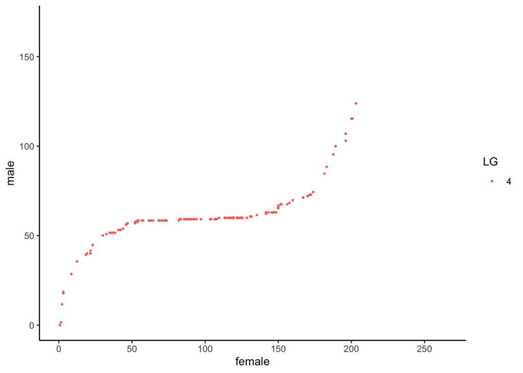

```r
i5 <- ggplot(maps.2 %>% filter(LG==4),
             aes(x=female, y=male,
                 group = LG, colour = LG)) +
  geom_point(size=0.5) + theme_classic() +
  scale_y_continuous(limits = c(0, 170),
                     breaks = seq(0, 150, by = 50)) +
  scale_x_continuous(limits = c(0,265),
                     breaks = seq(0, 250, by = 50))

i5
```

Now both maps start at 0cM!

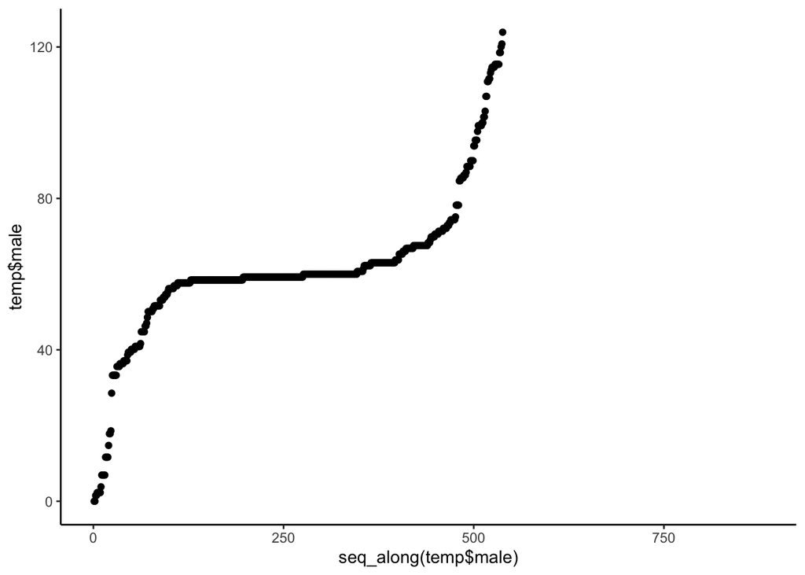

```r
temp <- maps.2 %>% filter(LG == 4) %>% arrange(male)

qplot(seq_along(temp$male), temp$male) +
  theme_classic()
```

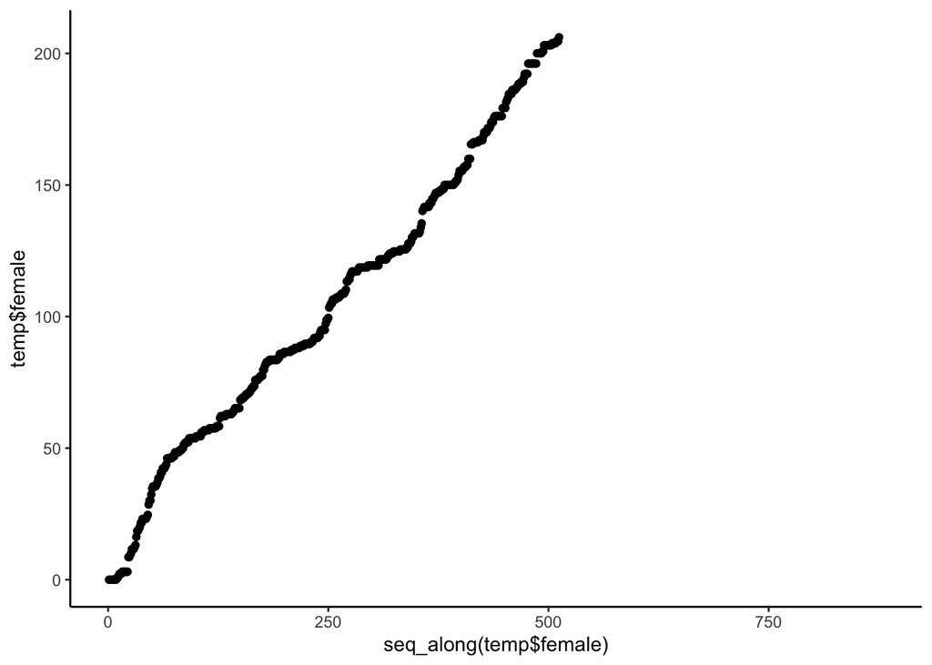

```r
temp <- maps.2 %>% filter(LG == 4) %>% arrange(female)

qplot(seq_along(temp$female), temp$female) +
  theme_classic()
```

And we can see that that long gap in the female map is gone. Thus, let’s proceed and replace the old map for LG4 with the new corrected one.

```r
#filter old LG map
maps <- maps %>% filter(LG != 4)

#concatenate to add new re-ordered maps
maps <- rbind(maps, maps.2)
```

Now let’s plot all 13 LGs again.

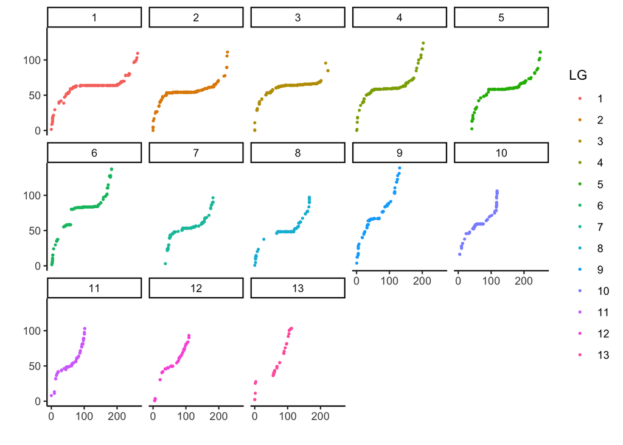

```r
# Remove any row with NAs
# these are the rows that include markers mapped only in the male or female map
# Thus, we will only be mapping markers heterozygous for both parents
maps.NA <- maps %>% drop_na()

# Plot the resulting data
i4 <- ggplot(maps.NA, aes(x=female, y=male,
                          group = LG, colour = LG)) +
  #facet by Linkage group
  geom_point(size=0.5) + facet_wrap(~LG, ncol = 5) +
  ylab("") + xlab("") +
  theme(strip.background = element_blank(),
        strip.text.x = element_blank()) +
  theme_classic()

i4
```

Finally, before moving on make sure to save the map file.

```r
write_delim(maps,
            file = "../6_reorder/6_2_fam1_maps.txt",
            delim = "\t",
            col_names = TRUE)
```

## 5. Plot maps with LinkageMapView

Finally, we will make nice plots of our linkage maps using the LinkageMapView package.

### 5.1. Load LinkageMapView

```r
library(LinkageMapView)
```

### 5.2. Calculate sex-average map

The sex-average map is usually calculated with (male+female)/2. So let’s do this accordingly.

```r
maps <- maps %>% mutate(
  sex.averaged = case_when(is.na(male) == TRUE ~ female,
                           is.na(female) ==  TRUE ~ male,
                           TRUE ~ (male+female)/2)
)
```

### 5.2. Format data for linkage map view

Now we have to convert to the required format (yay, another conversion).

```r
LMV_male <- maps %>%
  select(LG,male,SNPID) %>%
  drop_na() %>%
  rename(group = LG, position = male,
           locus = SNPID) %>%
  mutate(across(where(is.factor),
                  as.character)) %>%
  mutate(group = paste0(group, "M"))

LMV_female <- maps %>%
  select(LG,female,SNPID) %>%
  drop_na() %>%
  rename(group = LG, position = female,
           locus = SNPID) %>%
  mutate(across(where(is.factor),
                  as.character)) %>%
  mutate(group = paste0(group, "F"))

LMV_average <- maps %>%
  select(LG,sex.averaged,SNPID) %>%
  drop_na() %>%
  rename(group = LG, position = sex.averaged,
           locus = SNPID) %>%
  mutate(across(where(is.factor),
                  as.character)) %>%
  mutate(group = paste0(group, "A"))

my.map <- rbind(LMV_male, LMV_female, LMV_average)

levels <- c("1F","1M","1A",
            "2F","2M","2A",
            "3F","3M","3A",
            "4F","4M","4A",
            "5F","5M","5A",
            "6F","6M","6A",
            "7F","7M","7A",
            "8F","8M","8A",
            "9F","9M","9A",
            "10F","10M","10A",
            "11F","11M","11A",
            "12F","12M","12A",
            "13F","13M","13A")

my.map$group <- fct_relevel(my.map$group,
                        levels = levels)
```

And order the maps according to the position in cM

```r
my.map <- my.map[order(my.map$group,my.map$position),]
```

### 5.3. Plot density maps

```r
outfile = file.path("../7_LMVplots/7_1_maleMap_density.pdf")

lmv.linkage.plot(LMV_male,outfile,denmap=TRUE,
                 pdf.width = 15, pdf.height = 15,
                 cex.axis = 2,lgw = 0.30,cex.lgtitle = 2,
                 font.main = 2,cex.main = 3,
                 main="Male linkage maps")
```

```r
outfile = file.path("../7_LMVplots/7_1_femaleMap_density.pdf")

lmv.linkage.plot(LMV_female,outfile,denmap=TRUE,
                 pdf.width = 15, pdf.height = 15,
                 cex.axis = 2,lgw = 0.30,cex.lgtitle = 2,
                 font.main = 2,cex.main = 3,
                 main="Male linkage maps")
```

```r
outfile = file.path("../7_LMVplots/7_1_averageMap_density.pdf")

lmv.linkage.plot(LMV_average,outfile,denmap=TRUE,
                 pdf.width = 15, pdf.height = 15,
                 cex.axis = 2,lgw = 0.30,cex.lgtitle = 2,
                 font.main = 2,cex.main = 3,
                 main="Male linkage maps")
```

### 5.4. Plot black and white maps

Now let’s plot the male, female and sex-averaged linkage maps showing only the position of markers as black horizontal lines.

```r
outfile = file.path("../7_LMVplots/7_2_maleMap.pdf")

lmv.linkage.plot(LMV_male,outfile,
                 #need to use showonly to show only one marker, otherwise they get too dense and unreadable
                 showonly = c("25_8"),
                 ruler = TRUE,cex.axis = 2,
                 lgw = 0.30,
                 lgtitles = c("LG1","LG2","LG3","LG4",
                              "LG5","LG6","LG7","LG8",
                              "LG9","LG10","LG11","LG12",
                              "LG13"),
                 cex.lgtitle = 2,
                 pdf.width = 20, pdf.height = 18,
                 main="Male linkage maps",
                 font.main = 2,cex.main = 3)
```

```r
outfile = file.path("../7_LMVplots/7_2_femaleMap.pdf")

lmv.linkage.plot(LMV_female,outfile,
                 #need to use showonly to show only one marker, otherwise they get too dense and unreadable
                 showonly = c("27576_47"),
                 ruler = TRUE,cex.axis = 2,
                 lgw = 0.30,
                 lgtitles = c("LG1","LG2","LG3","LG4",
                              "LG5","LG6","LG7","LG8",
                              "LG9","LG10","LG11","LG12",
                              "LG13"),
                 cex.lgtitle = 2,
                 pdf.width = 20, pdf.height = 18,
                 main="Female linkage maps",
                 font.main = 2,cex.main = 3)
```

```r
outfile = file.path("../7_LMVplots/7_2_averageMap.pdf")

lmv.linkage.plot(LMV_average,outfile,
                 #need to use showonly to show only one marker, otherwise they get too dense and unreadable
                 showonly = c("25_8"),
                 ruler = TRUE,cex.axis = 2,
                 lgw = 0.30,
                 lgtitles = c("LG1","LG2","LG3","LG4",
                              "LG5","LG6","LG7","LG8",
                              "LG9","LG10","LG11","LG12",
                              "LG13"),
                 cex.lgtitle = 2,
                 pdf.width = 20, pdf.height = 18,
                 main="Sex-averaged linkage maps",
                 font.main = 2,cex.main = 3)
```

### 5.5. Plot male vs female maps